# Project: Investigate FBI Gun Data Set

## Christopher Hu

- Introduction
- Data Wrangling
- Exploratory Data Analysis
- Conclusions

## Introduction

> This data analysis report select 'FBI Gun Data set'. The two data files are 'gun_data.xlsx' and 'u.s.-census-data.csv'. gun_data.xlsx include the number of firearm checks by month, state, and type (recorded by NICS)  
> u.s.-census-data.csv contains variables at the state level. Most variables just have one data

> This report answer the following questions:

> **1) What census data is most associated with high gun per capita?**

> **2) Which states have had the highest growth in gun registrations?**

> **3) What is the overall trend of gun purchases?**

```python
# import statements
import pandas as pd
import numpy as np
import matplotlib.pyplot as plt
%matplotlib inline
import seaborn as sns

pd.set_option('display.max_columns', None)
pd.set_option('display.width', None)
```

```python
def plot_bar_graph(x, y, hue, title):
    """
    This function take two columns from a data frame, and run side by side barplot based on different group of data.
    reference: https://www.geeksforgeeks.org/seaborn-sort-bars-in-barplot/
    """
    fig, ax = plt.subplots(figsize=(24, 12))
    sns.barplot(x = x, y = y, hue=hue ).set(title=title)
    ax.set_xticklabels(ax.get_xticklabels(), rotation=90, horizontalalignment='center')
    plt.show()
```

## Data Wrangling

> In this section of the report, I loaded in the data, checked for cleanliness, and then trimmed and cleaned dataset for analysis. The steps were documented carefully and justify my cleaning decisions.

```python
# Load data and print out a few lines. Perform operations to inspect data
# types and look for instances of missing or possibly errant data.
df_gun_data = pd.read_excel('gun_data.xlsx')
df_gun_data.head(2)
```

|  | month | state | permit | permit_recheck | handgun | long_gun | other | multiple | admin | prepawn_handgun | prepawn_long_gun | prepawn_other | redemption_handgun | redemption_long_gun | redemption_other | returned_handgun | returned_long_gun | returned_other | rentals_handgun | rentals_long_gun | private_sale_handgun | private_sale_long_gun | private_sale_other | return_to_seller_handgun | return_to_seller_long_gun | return_to_seller_other | totals |
| --- | --- | --- | --- | --- | --- | --- | --- | --- | --- | --- | --- | --- | --- | --- | --- | --- | --- | --- | --- | --- | --- | --- | --- | --- | --- | --- | --- |
| 0 | 2017-09 | Alabama | 16717.0 | 0.0 | 5734.0 | 6320.0 | 221.0 | 317 | 0.0 | 15.0 | 21.0 | 2.0 | 1378.0 | 1262.0 | 1.0 | 0.0 | 0.0 | 0.0 | 0.0 | 0.0 | 9.0 | 16.0 | 3.0 | 0.0 | 0.0 | 3.0 | 32019 |
| 1 | 2017-09 | Alaska | 209.0 | 2.0 | 2320.0 | 2930.0 | 219.0 | 160 | 0.0 | 5.0 | 2.0 | 0.0 | 200.0 | 154.0 | 2.0 | 28.0 | 30.0 | 0.0 | 0.0 | 0.0 | 17.0 | 24.0 | 1.0 | 0.0 | 0.0 | 0.0 | 6303 |

```python
df_gun_data.info()
```

```
<class 'pandas.core.frame.DataFrame'>
RangeIndex: 12485 entries, 0 to 12484
Data columns (total 27 columns):
 #   Column                     Non-Null Count  Dtype
---  ------                     --------------  -----
 0   month                      12485 non-null  object
 1   state                      12485 non-null  object
 2   permit                     12461 non-null  float64
 3   permit_recheck             1100 non-null   float64
 4   handgun                    12465 non-null  float64
 5   long_gun                   12466 non-null  float64
 6   other                      5500 non-null   float64
 7   multiple                   12485 non-null  int64
 8   admin                      12462 non-null  float64
 9   prepawn_handgun            10542 non-null  float64
```

[output cut: 19 more lines]

```python
print("df_gun_data.duplicated().sum() = {}".format(df_gun_data.duplicated().sum()))
print("df_gun_data.shape = {}".format(df_gun_data.shape))
print("df_gun_data.isnull().sum()")
df_gun_data.isnull().sum()
```

```
df_gun_data.duplicated().sum() = 0
df_gun_data.shape = (12485, 27)
df_gun_data.isnull().sum()
```

```
month                            0
state                            0
permit                          24
permit_recheck               11385
handgun                         20
long_gun                        19
other                         6985
multiple                         0
admin                           23
prepawn_handgun               1943
prepawn_long_gun              1945
prepawn_other                 7370
redemption_handgun            1940
redemption_long_gun           1941
redemption_other              7370
returned_handgun             10285
returned_long_gun            10340
returned_other               10670
rentals_handgun              11495
rentals_long_gun             11660
private_sale_handgun          9735
private_sale_long_gun         9735
private_sale_other            9735
return_to_seller_handgun     10010
return_to_seller_long_gun     9735
return_to_seller_other       10230
totals                           0
dtype: int64
```

```python
# load the census data set and inspect the data set
df_census_data_temp = pd.read_csv('u.s.-census-data.csv', sep=',')
df_census_data_temp.head(2)
```

|  | Fact | Fact Note | Alabama | Alaska | Arizona | Arkansas | California | Colorado | Connecticut | Delaware | Florida | Georgia | Hawaii | Idaho | Illinois | Indiana | Iowa | Kansas | Kentucky | Louisiana | Maine | Maryland | Massachusetts | Michigan | Minnesota | Mississippi | Missouri | Montana | Nebraska | … |
| --- | --- | --- | --- | --- | --- | --- | --- | --- | --- | --- | --- | --- | --- | --- | --- | --- | --- | --- | --- | --- | --- | --- | --- | --- | --- | --- | --- | --- | --- | --- |
| 0 | Population estimates, July 1, 2016, (V2016) | NaN | 4,863,300 | 741,894 | 6,931,071 | 2,988,248 | 39,250,017 | 5,540,545 | 3,576,452 | 952,065 | 20,612,439 | 10,310,371 | 1,428,557 | 1,683,140 | 12,801,539 | 6,633,053 | 3,134,693 | 2,907,289 | 4,436,974 | 4,681,666 | 1,331,479 | 6,016,447 | 6,811,779 | 9,928,300 | 5,519,952 | 2,988,726 | 6,093,000 | 1,042,520 | 1,907,116 | … |
| 1 | Population estimates base, April 1, 2010, (V2... | NaN | 4,780,131 | 710,249 | 6,392,301 | 2,916,025 | 37,254,522 | 5,029,324 | 3,574,114 | 897,936 | 18,804,592 | 9,688,680 | 1,360,301 | 1,567,650 | 12,831,574 | 6,484,136 | 3,046,869 | 2,853,129 | 4,339,344 | 4,533,479 | 1,328,364 | 5,773,786 | 6,547,813 | 9,884,129 | 5,303,924 | 2,968,103 | 5,988,928 | 989,414 | 1,826,334 | … |

```python
df_census_data_temp.tail(2)
```

|  | Fact | Fact Note | Alabama | Alaska | Arizona | Arkansas | California | Colorado | Connecticut | Delaware | Florida | Georgia | Hawaii | Idaho | Illinois | Indiana | Iowa | Kansas | Kentucky | Louisiana | Maine | Maryland | Massachusetts | Michigan | Minnesota | Mississippi | Missouri | Montana | Nebraska | … |
| --- | --- | --- | --- | --- | --- | --- | --- | --- | --- | --- | --- | --- | --- | --- | --- | --- | --- | --- | --- | --- | --- | --- | --- | --- | --- | --- | --- | --- | --- | --- |
| 83 | X | Not applicable | NaN | NaN | NaN | NaN | NaN | NaN | NaN | NaN | NaN | NaN | NaN | NaN | NaN | NaN | NaN | NaN | NaN | NaN | NaN | NaN | NaN | NaN | NaN | NaN | NaN | NaN | NaN | … |
| 84 | Z | Value greater than zero but less than half uni... | NaN | NaN | NaN | NaN | NaN | NaN | NaN | NaN | NaN | NaN | NaN | NaN | NaN | NaN | NaN | NaN | NaN | NaN | NaN | NaN | NaN | NaN | NaN | NaN | NaN | NaN | NaN | … |

```python
print("df_census_data_temp.duplicated().sum() = {}".format(df_census_data_temp.duplicated().sum()))
print("df_census_data_temp.shape = {}".format(df_census_data_temp.shape))
print("df_census_data_temp.isnull().sum()")
df_census_data_temp.isnull().sum()
```

```
df_census_data_temp.duplicated().sum() = 3
df_census_data_temp.shape = (85, 52)
df_census_data_temp.isnull().sum()
```

```
Fact               5
Fact Note         57
Alabama           20
Alaska            20
Arizona           20
Arkansas          20
California        20
Colorado          20
Connecticut       20
Delaware          20
Florida           20
Georgia           20
Hawaii            20
Idaho             20
Illinois          20
Indiana           20
Iowa              20
Kansas            20
Kentucky          20
Louisiana         20
Maine             20
Maryland          20
Massachusetts     20
Michigan          20
Minnesota         20
Mississippi       20
Missouri          20
Montana           20
Nebraska          20
Nevada            20
New Hampshire     20
New Jersey        20
New Mexico        20
New York          20
North Carolina    20
North Dakota      20
Ohio              20
Oklahoma          20
Oregon            20
Pennsylvania      20
Rhode Island      20
South Carolina    20
South Dakota      20
Tennessee         20
Texas             20
Utah              20
Vermont           20
Virginia          20
Washington        20
West Virginia     20
Wisconsin         20
Wyoming           20
dtype: int64
```

```python
# since the gun data contain the monthly data for the same state, and I only need to check how may states here
# total 55 states
df_gun_data[df_gun_data['month']=='2016-07'].shape
```

```
(55, 27)
```

> **Observation 1 - for gun_data**: The data are collected over the years for all the states. All the rows are unique and there are lots of null values and 0 values.  
> **Observation 2 - for census data**: the census data file collect different kind of data for all the states. We can use the relavent population data to calculate #of check per Capita (which is related to #of check per 1000 people). Also there are some notes and cell with characters in numeric columns and we need to clean them. Also census data need to be transposed to match gun_data in order to do statistical calulations  
> **Observation 3 - for both data**: It seems census data only have two month of population are related to gun_data. Also the number of states are slightly different and hence some states in gun_data needs to be dropped as well

### Data Cleaning

> **for gun_data set**: since there are lots of nulls and 0s for some of the columns in gun data set. It is a good idea to just fill all the null values to 0.

```python
# All the cells with NA are filled with 0.  Therefore 0 represents either no background checks is recorded or no background check
# and convert columns 'multiple' and 'totals' into float
df_gun_data.fillna(0, inplace=True)
print(df_gun_data.info())
```

```
<class 'pandas.core.frame.DataFrame'>
RangeIndex: 12485 entries, 0 to 12484
Data columns (total 27 columns):
 #   Column                     Non-Null Count  Dtype
---  ------                     --------------  -----
 0   month                      12485 non-null  object
 1   state                      12485 non-null  object
 2   permit                     12485 non-null  float64
 3   permit_recheck             12485 non-null  float64
 4   handgun                    12485 non-null  float64
 5   long_gun                   12485 non-null  float64
 6   other                      12485 non-null  float64
 7   multiple                   12485 non-null  int64
 8   admin                      12485 non-null  float64
 9   prepawn_handgun            12485 non-null  float64
```

[output cut: 20 more lines]

### Data Cleaning

> **for census data:**:  
> 1) drop column 'Fact Note'  
> 2) drop rows from 64 and beyond since that are all notes, and has nothing to do with stats calculation  
> 3) rename column 'Fact' to 'state' for gun per capita calculation and plot display  
> 4) Transpose census data to match gun data format for easy plotting  
> 5) fix column name, and data content (such as 'D', 'F' etc)  
> 6) replace ',' as '' to reform the numbers (e.g. 4,500 to 4500), remove % for column represented in %, removed \$ sign for numbers that represents currency

```python
df_census_data_temp.head(2)
```

|  | Fact | Fact Note | Alabama | Alaska | Arizona | Arkansas | California | Colorado | Connecticut | Delaware | Florida | Georgia | Hawaii | Idaho | Illinois | Indiana | Iowa | Kansas | Kentucky | Louisiana | Maine | Maryland | Massachusetts | Michigan | Minnesota | Mississippi | Missouri | Montana | Nebraska | … |
| --- | --- | --- | --- | --- | --- | --- | --- | --- | --- | --- | --- | --- | --- | --- | --- | --- | --- | --- | --- | --- | --- | --- | --- | --- | --- | --- | --- | --- | --- | --- |
| 0 | Population estimates, July 1, 2016, (V2016) | NaN | 4,863,300 | 741,894 | 6,931,071 | 2,988,248 | 39,250,017 | 5,540,545 | 3,576,452 | 952,065 | 20,612,439 | 10,310,371 | 1,428,557 | 1,683,140 | 12,801,539 | 6,633,053 | 3,134,693 | 2,907,289 | 4,436,974 | 4,681,666 | 1,331,479 | 6,016,447 | 6,811,779 | 9,928,300 | 5,519,952 | 2,988,726 | 6,093,000 | 1,042,520 | 1,907,116 | … |
| 1 | Population estimates base, April 1, 2010, (V2... | NaN | 4,780,131 | 710,249 | 6,392,301 | 2,916,025 | 37,254,522 | 5,029,324 | 3,574,114 | 897,936 | 18,804,592 | 9,688,680 | 1,360,301 | 1,567,650 | 12,831,574 | 6,484,136 | 3,046,869 | 2,853,129 | 4,339,344 | 4,533,479 | 1,328,364 | 5,773,786 | 6,547,813 | 9,884,129 | 5,303,924 | 2,968,103 | 5,988,928 | 989,414 | 1,826,334 | … |

```python
# The following code drop unwanted column and rows
df_census_data_temp.drop('Fact Note', axis=1, inplace=True)
df_census_data_temp.drop(df_census_data_temp.index[64:], inplace=True)
df_census_data_temp.rename(columns={"Fact":"state"}, inplace=True)
```

```python
# The following code is to transpose the table to match gun_data
df_census_data_temp_transposed = df_census_data_temp.T
df_census_data_temp_transposed.head()
```

|  | 0 | 1 | 2 | 3 | 4 | 5 | 6 | 7 | 8 | 9 | 10 | 11 | 12 | 13 | 14 | 15 | 16 | 17 | 18 | 19 | 20 | 21 | 22 | 23 | 24 | 25 | 26 | 27 | 28 | … |
| --- | --- | --- | --- | --- | --- | --- | --- | --- | --- | --- | --- | --- | --- | --- | --- | --- | --- | --- | --- | --- | --- | --- | --- | --- | --- | --- | --- | --- | --- | --- |
| state | Population estimates, July 1, 2016, (V2016) | Population estimates base, April 1, 2010, (V2... | Population, percent change - April 1, 2010 (es... | Population, Census, April 1, 2010 | Persons under 5 years, percent, July 1, 2016, ... | Persons under 5 years, percent, April 1, 2010 | Persons under 18 years, percent, July 1, 2016,... | Persons under 18 years, percent, April 1, 2010 | Persons 65 years and over, percent, July 1, 2... | Persons 65 years and over, percent, April 1, 2010 | Female persons, percent, July 1, 2016, (V2016) | Female persons, percent, April 1, 2010 | White alone, percent, July 1, 2016, (V2016) | Black or African American alone, percent, July... | American Indian and Alaska Native alone, perce... | Asian alone, percent, July 1, 2016, (V2016) | Native Hawaiian and Other Pacific Islander alo... | Two or More Races, percent, July 1, 2016, (V2... | Hispanic or Latino, percent, July 1, 2016, (V... | White alone, not Hispanic or Latino, percent, ... | Veterans, 2011-2015 | Foreign born persons, percent, 2011-2015 | Housing units, July 1, 2016, (V2016) | Housing units, April 1, 2010 | Owner-occupied housing unit rate, 2011-2015 | Median value of owner-occupied housing units, ... | Median selected monthly owner costs -with a mo... | Median selected monthly owner costs -without a... | Median gross rent, 2011-2015 | … |
| Alabama | 4,863,300 | 4,780,131 | 1.70% | 4,779,736 | 6.00% | 6.40% | 22.60% | 23.70% | 16.10% | 13.80% | 51.60% | 51.50% | 69.30% | 26.80% | 0.70% | 1.40% | 0.10% | 1.60% | 4.20% | 65.80% | 363,170 | 3.50% | 2,230,185 | 2,171,853 | 68.70% | $125,500 | $1,139 | $345 | $717 | … |
| Alaska | 741,894 | 710,249 | 4.50% | 710,231 | 7.30% | 7.60% | 25.20% | 26.40% | 10.40% | 7.70% | 47.70% | 48.00% | 66.10% | 3.80% | 15.20% | 6.30% | 1.30% | 7.30% | 7.00% | 61.20% | 69,323 | 7.40% | 310,658 | 306,967 | 63.40% | $250,000 | $1,827 | $554 | $1,146 | … |
| Arizona | 6,931,071 | 6,392,301 | 8.40% | 6,392,017 | 6.30% | 7.10% | 23.50% | 25.50% | 16.90% | 13.80% | 50.30% | 50.30% | 83.30% | 4.90% | 5.40% | 3.40% | 0.30% | 2.80% | 30.90% | 55.50% | 505,794 | 13.50% | 2,961,003 | 2,844,526 | 62.80% | $167,500 | $1,343 | $380 | $913 | … |
| Arkansas | 2,988,248 | 2,916,025 | 2.50% | 2,915,918 | 6.40% | 6.80% | 23.60% | 24.40% | 16.30% | 14.40% | 50.90% | 50.90% | 79.40% | 15.70% | 1.00% | 1.60% | 0.30% | 2.00% | 7.30% | 72.90% | 220,953 | 4.70% | 1,354,762 | 1,316,299 | 66.10% | $111,400 | $1,019 | $327 | $677 | … |

```python
df_census_data_temp_transposed=df_census_data_temp_transposed.replace(r'^D$', np.nan, regex=True)
df_census_data_temp_transposed=df_census_data_temp_transposed.replace(r'^D$', np.nan, regex=True)
df_census_data_temp_transposed=df_census_data_temp_transposed.replace(r'^F$', np.nan, regex=True)
df_census_data_temp_transposed=df_census_data_temp_transposed.replace(r'^FN$', np.nan, regex=True)
df_census_data_temp_transposed=df_census_data_temp_transposed.replace(r'^NA$', np.nan, regex=True)
df_census_data_temp_transposed=df_census_data_temp_transposed.replace(r'^S$', np.nan, regex=True)
df_census_data_temp_transposed=df_census_data_temp_transposed.replace(r'^X$', np.nan, regex=True)
df_census_data_temp_transposed=df_census_data_temp_transposed.replace(r'^Z$', np.nan, regex=True)
df_census_data_temp_transposed=df_census_data_temp_transposed.replace('%', '', regex=True)
df_census_data_temp_transposed=df_census_data_temp_transposed.replace(',', '', regex=True)
df_census_data_temp_transposed=df_census_data_temp_transposed.replace(', ', '_', regex=True)
df_census_data_temp_transposed=df_census_data_temp_transposed.replace(' ', '', regex=True)
df_census_data_temp_transposed=df_census_data_temp_transposed.replace('[\$,]', '', regex=True)
df_census_data_temp_transposed.fillna(0).head(5)
```

|  | 0 | 1 | 2 | 3 | 4 | 5 | 6 | 7 | 8 | 9 | 10 | 11 | 12 | 13 | 14 | 15 | 16 | 17 | 18 | 19 | 20 | 21 | 22 | 23 | 24 | 25 | 26 | 27 | 28 | … |
| --- | --- | --- | --- | --- | --- | --- | --- | --- | --- | --- | --- | --- | --- | --- | --- | --- | --- | --- | --- | --- | --- | --- | --- | --- | --- | --- | --- | --- | --- | --- |
| state | PopulationestimatesJuly12016(V2016) | PopulationestimatesbaseApril12010(V2016) | Populationpercentchange-April12010(estimatesba... | PopulationCensusApril12010 | Personsunder5yearspercentJuly12016(V2016) | Personsunder5yearspercentApril12010 | Personsunder18yearspercentJuly12016(V2016) | Personsunder18yearspercentApril12010 | Persons65yearsandoverpercentJuly12016(V2016) | Persons65yearsandoverpercentApril12010 | FemalepersonspercentJuly12016(V2016) | FemalepersonspercentApril12010 | WhitealonepercentJuly12016(V2016) | BlackorAfricanAmericanalonepercentJuly12016(V2... | AmericanIndianandAlaskaNativealonepercentJuly1... | AsianalonepercentJuly12016(V2016) | NativeHawaiianandOtherPacificIslanderaloneperc... | TwoorMoreRacespercentJuly12016(V2016) | HispanicorLatinopercentJuly12016(V2016) | WhitealonenotHispanicorLatinopercentJuly12016(... | Veterans2011-2015 | Foreignbornpersonspercent2011-2015 | HousingunitsJuly12016(V2016) | HousingunitsApril12010 | Owner-occupiedhousingunitrate2011-2015 | Medianvalueofowner-occupiedhousingunits2011-2015 | Medianselectedmonthlyownercosts-withamortgage2... | Medianselectedmonthlyownercosts-withoutamortga... | Mediangrossrent2011-2015 | … |
| Alabama | 4863300 | 4780131 | 1.70 | 4779736 | 6.00 | 6.40 | 22.60 | 23.70 | 16.10 | 13.80 | 51.60 | 51.50 | 69.30 | 26.80 | 0.70 | 1.40 | 0.10 | 1.60 | 4.20 | 65.80 | 363170 | 3.50 | 2230185 | 2171853 | 68.70 | 125500 | 1139 | 345 | 717 | … |
| Alaska | 741894 | 710249 | 4.50 | 710231 | 7.30 | 7.60 | 25.20 | 26.40 | 10.40 | 7.70 | 47.70 | 48.00 | 66.10 | 3.80 | 15.20 | 6.30 | 1.30 | 7.30 | 7.00 | 61.20 | 69323 | 7.40 | 310658 | 306967 | 63.40 | 250000 | 1827 | 554 | 1146 | … |
| Arizona | 6931071 | 6392301 | 8.40 | 6392017 | 6.30 | 7.10 | 23.50 | 25.50 | 16.90 | 13.80 | 50.30 | 50.30 | 83.30 | 4.90 | 5.40 | 3.40 | 0.30 | 2.80 | 30.90 | 55.50 | 505794 | 13.50 | 2961003 | 2844526 | 62.80 | 167500 | 1343 | 380 | 913 | … |
| Arkansas | 2988248 | 2916025 | 2.50 | 2915918 | 6.40 | 6.80 | 23.60 | 24.40 | 16.30 | 14.40 | 50.90 | 50.90 | 79.40 | 15.70 | 1.00 | 1.60 | 0.30 | 2.00 | 7.30 | 72.90 | 220953 | 4.70 | 1354762 | 1316299 | 66.10 | 111400 | 1019 | 327 | 677 | … |

```python
# save it for reprocess
df_census_data_temp_transposed.to_csv('df_census_data_transposed.csv', index=True)
```

```python
## reload census data, and fix all the column names
df_census_data = pd.read_csv("df_census_data_transposed.csv", sep=',', header=1)
```

```python
df_census_data.info()
```

```
<class 'pandas.core.frame.DataFrame'>
RangeIndex: 50 entries, 0 to 49
Data columns (total 65 columns):
 #   Column                                                                   Non-Null Count  Dtype
---  ------                                                                   --------------  -----
 0   state                                                                    50 non-null     object
 1   PopulationestimatesJuly12016(V2016)                                      50 non-null     int64
 2   PopulationestimatesbaseApril12010(V2016)                                 50 non-null     int64
 3   Populationpercentchange-April12010(estimatesbase)toJuly12016(V2016)      50 non-null     float64
 4   PopulationCensusApril12010                                               50 non-null     int64
 5   Personsunder5yearspercentJuly12016(V2016)                                50 non-null     float64
 6   Personsunder5yearspercentApril12010                                      50 non-null     float64
 7   Personsunder18yearspercentJuly12016(V2016)                               50 non-null     float64
 8   Personsunder18yearspercentApril12010                                     50 non-null     float64
 9   Persons65yearsandoverpercentJuly12016(V2016)                             50 non-null     float64
```

[output cut: 57 more lines]

```python
df_census_data.head(2)
```

|  | state | PopulationestimatesJuly12016(V2016) | PopulationestimatesbaseApril12010(V2016) | Populationpercentchange-April12010(estimatesbase)toJuly12016(V2016) | PopulationCensusApril12010 | Personsunder5yearspercentJuly12016(V2016) | Personsunder5yearspercentApril12010 | Personsunder18yearspercentJuly12016(V2016) | Personsunder18yearspercentApril12010 | Persons65yearsandoverpercentJuly12016(V2016) | Persons65yearsandoverpercentApril12010 | FemalepersonspercentJuly12016(V2016) | FemalepersonspercentApril12010 | WhitealonepercentJuly12016(V2016) | BlackorAfricanAmericanalonepercentJuly12016(V2016) | AmericanIndianandAlaskaNativealonepercentJuly12016(V2016) | AsianalonepercentJuly12016(V2016) | NativeHawaiianandOtherPacificIslanderalonepercentJuly12016(V2016) | TwoorMoreRacespercentJuly12016(V2016) | HispanicorLatinopercentJuly12016(V2016) | WhitealonenotHispanicorLatinopercentJuly12016(V2016) | Veterans2011-2015 | Foreignbornpersonspercent2011-2015 | HousingunitsJuly12016(V2016) | HousingunitsApril12010 | Owner-occupiedhousingunitrate2011-2015 | Medianvalueofowner-occupiedhousingunits2011-2015 | Medianselectedmonthlyownercosts-withamortgage2011-2015 | Medianselectedmonthlyownercosts-withoutamortgage2011-2015 | … |
| --- | --- | --- | --- | --- | --- | --- | --- | --- | --- | --- | --- | --- | --- | --- | --- | --- | --- | --- | --- | --- | --- | --- | --- | --- | --- | --- | --- | --- | --- | --- |
| 0 | Alabama | 4863300 | 4780131 | 1.7 | 4779736 | 6.0 | 6.4 | 22.6 | 23.7 | 16.1 | 13.8 | 51.6 | 51.5 | 69.3 | 26.8 | 0.7 | 1.4 | 0.1 | 1.6 | 4.2 | 65.8 | 363170 | 3.5 | 2230185 | 2171853 | 68.7 | 125500 | 1139 | 345 | … |
| 1 | Alaska | 741894 | 710249 | 4.5 | 710231 | 7.3 | 7.6 | 25.2 | 26.4 | 10.4 | 7.7 | 47.7 | 48.0 | 66.1 | 3.8 | 15.2 | 6.3 | 1.3 | 7.3 | 7.0 | 61.2 | 69323 | 7.4 | 310658 | 306967 | 63.4 | 250000 | 1827 | 554 | … |

```python
df_census_data.shape
```

```
(50, 65)
```

### Data Cleaning - matching states between gun data and census data with same states

```python
# get all the states from gun_data into a list
gun_state_list = df_gun_data.state.unique().tolist()
```

```python
# get all the states from transposed census data into a list
census_state_list = df_census_data.state.unique().tolist()
```

```python
# do a difference bewteen two list
for st in census_state_list:
    #print(st)
    gun_state_list.remove(st)
```

```python
# the remain state from gun_state_list are NOT appearing in census data set, so we need to further remove the data with these steate
print(gun_state_list)
```

```
['District of Columbia', 'Guam', 'Mariana Islands', 'Puerto Rico', 'Virgin Islands']
```

```python
# drop state in ['District of Columbia', 'Guam', 'Mariana Islands', 'Puerto Rico', 'Virgin Islands'] from df_gun_data dataframe
for st in gun_state_list:
    df_gun_data.drop(df_gun_data[df_gun_data.state == st].index, inplace=True)
```

```python
print(df_gun_data[df_gun_data['month']=='2016-07'].shape)
print(df_census_data.shape)
```

```
(50, 27)
(50, 65)
```

### Data subsetting and concat

> **for df_gun_data:**: 1) we only need a subset from month 2010-04 and 2016-07  
> **for df_census_data_clean**: 1) we need concat month 2010-04 and month 2016-07 polulation data to gun data  
> **both need to be reindexed appended data before we can combine them in one table to calculating gun per captica**

```python
# reference: https://statisticsglobe.com/reindex-pandas-dataframe-python
df_gun_data_2010_2016 = df_gun_data.query("(month == '2016-07') or (month == '2010-04')")
df_gun_data_2010_2016 = df_gun_data_2010_2016.reset_index(drop=True)
```

```python
# the following is to combine year 2016-07 and 2010-04 population data together from clean census data table
# 2017
df_new_population_201607 = df_census_data[['state', 'PopulationestimatesJuly12016(V2016)']].copy()
df_new_population_201607['year_month'] = '2016_07'
df_new_population_201607.rename(columns={'PopulationestimatesJuly12016(V2016)':'Population'}, inplace=True)
df_new_population_201607.head(2)
```

|  | state | Population | year_month |
| --- | --- | --- | --- |
| 0 | Alabama | 4863300 | 2016_07 |
| 1 | Alaska | 741894 | 2016_07 |

```python
# 2014
df_new_population_201004 = df_census_data[['state', 'PopulationCensusApril12010']].copy()
df_new_population_201004['year_month'] = '2010_04'
df_new_population_201004.rename(columns={'PopulationCensusApril12010':'Population'}, inplace=True)
df_new_population_201004.head(2)
```

|  | state | Population | year_month |
| --- | --- | --- | --- |
| 0 | Alabama | 4779736 | 2010_04 |
| 1 | Alaska | 710231 | 2010_04 |

```python
# concat 2017 and 2014
df_new_population_combine =pd.concat([df_new_population_201607, df_new_population_201004])
# reindex
df_new_population_combine = df_new_population_combine.reset_index(drop=True)
df_new_population_combine
```

|  | state | Population | year_month |
| --- | --- | --- | --- |
| 0 | Alabama | 4863300 | 2016_07 |
| 1 | Alaska | 741894 | 2016_07 |
| 2 | Arizona | 6931071 | 2016_07 |
| 3 | Arkansas | 2988248 | 2016_07 |
| 4 | California | 39250017 | 2016_07 |
| ... | ... | ... | ... |
| 95 | Virginia | 8001024 | 2010_04 |
| 96 | Washington | 6724540 | 2010_04 |
| 97 | West Virginia | 1852994 | 2010_04 |
| 98 | Wisconsin | 5686986 | 2010_04 |
| 99 | Wyoming | 563626 | 2010_04 |

100 rows × 3 columns

### Data combination - gun data and census data combine to calculate stats

> 1) now df_gun_data_2010_2016 has one additional column: population  
> 2) more columns can be added to run stats

```python
# add a column in df_gun_data_2010_2016 from df_new_population_combine (census)
df_gun_data_2010_2016['Population'] = df_new_population_combine['Population']
```

```python
df_gun_data_2010_2016.shape
```

```
(100, 28)
```

```python
df_gun_data_2010_2016.head(5)
```

|  | month | state | permit | permit_recheck | handgun | long_gun | other | multiple | admin | prepawn_handgun | prepawn_long_gun | prepawn_other | redemption_handgun | redemption_long_gun | redemption_other | returned_handgun | returned_long_gun | returned_other | rentals_handgun | rentals_long_gun | private_sale_handgun | private_sale_long_gun | private_sale_other | return_to_seller_handgun | return_to_seller_long_gun | return_to_seller_other | totals | Population |
| --- | --- | --- | --- | --- | --- | --- | --- | --- | --- | --- | --- | --- | --- | --- | --- | --- | --- | --- | --- | --- | --- | --- | --- | --- | --- | --- | --- | --- |
| 0 | 2016-07 | Alabama | 27765.0 | 0.0 | 10132.0 | 7392.0 | 538.0 | 465 | 0.0 | 5.0 | 3.0 | 0.0 | 1457.0 | 1151.0 | 3.0 | 0.0 | 0.0 | 0.0 | 0.0 | 0.0 | 9.0 | 5.0 | 0.0 | 1.0 | 1.0 | 0.0 | 48927 | 4863300 |
| 1 | 2016-07 | Alaska | 215.0 | 0.0 | 2898.0 | 2816.0 | 239.0 | 165 | 0.0 | 7.0 | 10.0 | 0.0 | 200.0 | 178.0 | 4.0 | 20.0 | 16.0 | 0.0 | 0.0 | 0.0 | 7.0 | 17.0 | 0.0 | 1.0 | 0.0 | 0.0 | 6793 | 741894 |
| 2 | 2016-07 | Arizona | 7863.0 | 308.0 | 13693.0 | 8643.0 | 1283.0 | 642 | 0.0 | 5.0 | 10.0 | 0.0 | 1272.0 | 631.0 | 7.0 | 103.0 | 13.0 | 0.0 | 0.0 | 0.0 | 13.0 | 9.0 | 0.0 | 0.0 | 1.0 | 0.0 | 34496 | 6931071 |
| 3 | 2016-07 | Arkansas | 4116.0 | 677.0 | 6323.0 | 5053.0 | 325.0 | 367 | 2.0 | 6.0 | 14.0 | 0.0 | 1001.0 | 1476.0 | 4.0 | 0.0 | 0.0 | 0.0 | 0.0 | 0.0 | 7.0 | 5.0 | 1.0 | 0.0 | 1.0 | 0.0 | 19378 | 2988248 |
| 4 | 2016-07 | California | 77962.0 | 0.0 | 46361.0 | 47594.0 | 17297.0 | 0 | 0.0 | 0.0 | 0.0 | 0.0 | 492.0 | 504.0 | 8.0 | 0.0 | 0.0 | 0.0 | 0.0 | 0.0 | 0.0 | 0.0 | 0.0 | 0.0 | 0.0 | 0.0 | 190218 | 39250017 |

## Exploratory Data Analysis

### Research Question 1 What census data is most associated with high gun per capita?

> 1) First we need to calculate permit per capita in gun data set  
> 2) Then we need to move the permit per capita back to census data so that we can plot bar plot against state for all columns to see which fact is most associated with high permit per capita

#### population distribution for all states in 2010-04 and 2016-07

> The following bar graph show side by side comparison of the population distribution for all the states (NOT include District of Columbia, Guam, Mariana Islands, Puerto Rico, and Virgin Islands). It shows that California has the most population, followed by Texas.

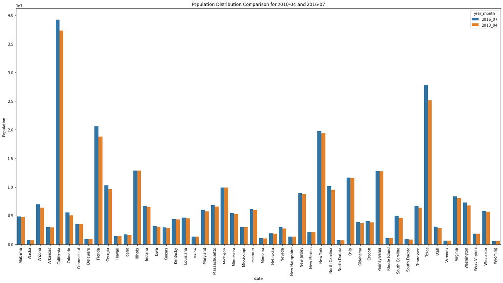

```python
plot_bar_graph(df_new_population_combine.state, df_new_population_combine.Population,
              df_new_population_combine.year_month, "Population Distribution Comparison for 2010-04 and 2016-07")
```

```python
# calculate permit per capita
df_gun_data_2010_2016['permit_per_capita'] = df_gun_data_2010_2016.permit * 1000 / df_gun_data_2010_2016.Population
df_gun_data_2010_2016
```

|  | month | state | permit | permit_recheck | handgun | long_gun | other | multiple | admin | prepawn_handgun | prepawn_long_gun | prepawn_other | redemption_handgun | redemption_long_gun | redemption_other | returned_handgun | returned_long_gun | returned_other | rentals_handgun | rentals_long_gun | private_sale_handgun | private_sale_long_gun | private_sale_other | return_to_seller_handgun | return_to_seller_long_gun | return_to_seller_other | totals | Population | permit_per_capita |
| --- | --- | --- | --- | --- | --- | --- | --- | --- | --- | --- | --- | --- | --- | --- | --- | --- | --- | --- | --- | --- | --- | --- | --- | --- | --- | --- | --- | --- | --- |
| 0 | 2016-07 | Alabama | 27765.0 | 0.0 | 10132.0 | 7392.0 | 538.0 | 465 | 0.0 | 5.0 | 3.0 | 0.0 | 1457.0 | 1151.0 | 3.0 | 0.0 | 0.0 | 0.0 | 0.0 | 0.0 | 9.0 | 5.0 | 0.0 | 1.0 | 1.0 | 0.0 | 48927 | 4863300 | 5.709086 |
| 1 | 2016-07 | Alaska | 215.0 | 0.0 | 2898.0 | 2816.0 | 239.0 | 165 | 0.0 | 7.0 | 10.0 | 0.0 | 200.0 | 178.0 | 4.0 | 20.0 | 16.0 | 0.0 | 0.0 | 0.0 | 7.0 | 17.0 | 0.0 | 1.0 | 0.0 | 0.0 | 6793 | 741894 | 0.289799 |
| 2 | 2016-07 | Arizona | 7863.0 | 308.0 | 13693.0 | 8643.0 | 1283.0 | 642 | 0.0 | 5.0 | 10.0 | 0.0 | 1272.0 | 631.0 | 7.0 | 103.0 | 13.0 | 0.0 | 0.0 | 0.0 | 13.0 | 9.0 | 0.0 | 0.0 | 1.0 | 0.0 | 34496 | 6931071 | 1.134457 |
| 3 | 2016-07 | Arkansas | 4116.0 | 677.0 | 6323.0 | 5053.0 | 325.0 | 367 | 2.0 | 6.0 | 14.0 | 0.0 | 1001.0 | 1476.0 | 4.0 | 0.0 | 0.0 | 0.0 | 0.0 | 0.0 | 7.0 | 5.0 | 1.0 | 0.0 | 1.0 | 0.0 | 19378 | 2988248 | 1.377396 |
| 4 | 2016-07 | California | 77962.0 | 0.0 | 46361.0 | 47594.0 | 17297.0 | 0 | 0.0 | 0.0 | 0.0 | 0.0 | 492.0 | 504.0 | 8.0 | 0.0 | 0.0 | 0.0 | 0.0 | 0.0 | 0.0 | 0.0 | 0.0 | 0.0 | 0.0 | 0.0 | 190218 | 39250017 | 1.986292 |
| ... | ... | ... | ... | ... | ... | ... | ... | ... | ... | ... | ... | ... | ... | ... | ... | ... | ... | ... | ... | ... | ... | ... | ... | ... | ... | ... | ... | ... | ... |
| 95 | 2010-04 | Virginia | 0.0 | 0.0 | 25259.0 | 18158.0 | 0.0 | 720 | 0.0 | 0.0 | 0.0 | 0.0 | 0.0 | 0.0 | 0.0 | 0.0 | 0.0 | 0.0 | 0.0 | 0.0 | 0.0 | 0.0 | 0.0 | 0.0 | 0.0 | 0.0 | 44137 | 8001024 | 0.000000 |
| 96 | 2010-04 | Washington | 6830.0 | 0.0 | 10384.0 | 7986.0 | 347.0 | 369 | 1.0 | 2.0 | 5.0 | 0.0 | 873.0 | 1019.0 | 0.0 | 0.0 | 0.0 | 0.0 | 0.0 | 0.0 | 0.0 | 0.0 | 0.0 | 0.0 | 0.0 | 0.0 | 27816 | 6724540 | 1.015683 |
| 97 | 2010-04 | West Virginia | 0.0 | 0.0 | 3927.0 | 4534.0 | 53.0 | 263 | 0.0 | 1.0 | 16.0 | 0.0 | 704.0 | 1680.0 | 2.0 | 0.0 | 0.0 | 0.0 | 0.0 | 0.0 | 0.0 | 0.0 | 0.0 | 0.0 | 0.0 | 0.0 | 11180 | 1852994 | 0.000000 |
| 98 | 2010-04 | Wisconsin | 0.0 | 0.0 | 5414.0 | 10701.0 | 108.0 | 7 | 0.0 | 0.0 | 3.0 | 0.0 | 7.0 | 231.0 | 0.0 | 0.0 | 0.0 | 0.0 | 0.0 | 0.0 | 0.0 | 0.0 | 0.0 | 0.0 | 0.0 | 0.0 | 16471 | 5686986 | 0.000000 |
| 99 | 2010-04 | Wyoming | 532.0 | 0.0 | 1295.0 | 1700.0 | 38.0 | 82 | 35.0 | 0.0 | 6.0 | 0.0 | 96.0 | 229.0 | 0.0 | 0.0 | 0.0 | 0.0 | 0.0 | 0.0 | 0.0 | 0.0 | 0.0 | 0.0 | 0.0 | 0.0 | 4013 | 563626 | 0.943888 |

100 rows × 29 columns

### Comparison of permit per capita for 2010-04 and 2016-07

> 1) The following graph indicates Kentucky has a very high permit check per capita and therefore most likely gun per capita is also very high  
> 2) Most of the state has a increase of permit check per capita from 2010-04 to 2016-07. Only Utah has a big drop on permit check per capita  
> 3) Although California and Texas have a high number of population, but gun per capita are not that high compare to other states such as Illinois, Indiana, Kentucky

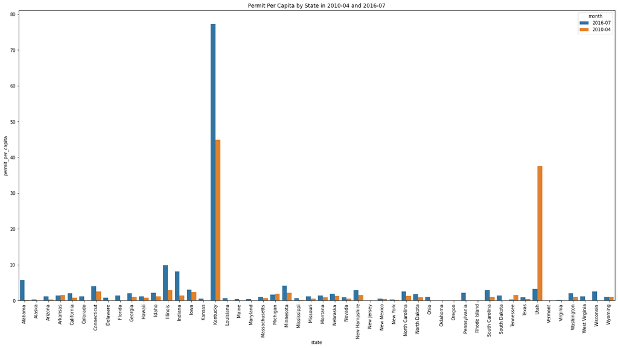

```python
plot_bar_graph(df_gun_data_2010_2016.state,df_gun_data_2010_2016.permit_per_capita,
              df_gun_data_2010_2016.month, "Permit Per Capita by State in 2010-04 and 2016-07")
```

### Comparison of All type gun background check per capita for 2010-04 and 2016-07

> 1) The following graph are comparing all type of gun background check per capita for all states in 2010-04 and 2016-07  
> 2) The distribution pattern is very similar to that of "Permit Per Capita by State in 2010-04 and 2016-07" graph

```python
df_gun_data_2010_2016['all_type_check'] = df_gun_data_2010_2016['totals']*1000/df_gun_data_2010_2016.Population
```

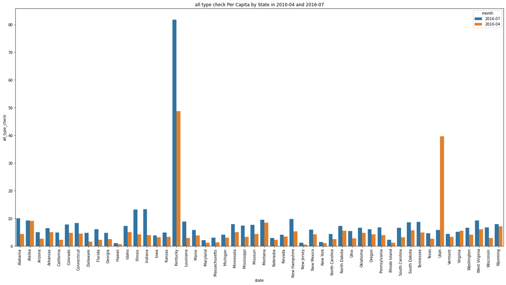

```python
plot_bar_graph(df_gun_data_2010_2016.state, df_gun_data_2010_2016.all_type_check,
              df_gun_data_2010_2016.month, "all type check Per Capita by State in 2010-04 and 2016-07")
```

### The following are adding all check per capita into transposed census data set so that we can see which state has the highest growth rate in term of # of background check from 2010-04 to 2016-07

### answer to Question #2 - Which states have had the highest growth in gun registrations

> 1) From the bar graph below, **Indiana** has the highest growth rate of all the states: roughly 240% increase of all type background check  
> 2) **Utah** and **Virginia** has decline in total background check

```python
# move permit per capita back to census data by year
df_gun_data_2016_07_capita=df_gun_data_2010_2016.query("month == '2016-07'")['all_type_check']
df_gun_data_2016_07_capita_reindex = df_gun_data_2016_07_capita.reset_index(drop=True)
```

```python
df_gun_data_2010_04_capita=df_gun_data_2010_2016.query("month == '2010-04'")['all_type_check']
df_gun_data_2010_04_capita_reindex = df_gun_data_2010_04_capita.reset_index(drop=True)
```

```python
df_census_data['all_type_check_per_capita_2016_07'] = df_gun_data_2016_07_capita_reindex
df_census_data['all_type_check_per_capita_2010_04'] = df_gun_data_2010_04_capita_reindex
df_census_data.head(2)
#df_census_data_clean.info()
```

|  | state | PopulationestimatesJuly12016(V2016) | PopulationestimatesbaseApril12010(V2016) | Populationpercentchange-April12010(estimatesbase)toJuly12016(V2016) | PopulationCensusApril12010 | Personsunder5yearspercentJuly12016(V2016) | Personsunder5yearspercentApril12010 | Personsunder18yearspercentJuly12016(V2016) | Personsunder18yearspercentApril12010 | Persons65yearsandoverpercentJuly12016(V2016) | Persons65yearsandoverpercentApril12010 | FemalepersonspercentJuly12016(V2016) | FemalepersonspercentApril12010 | WhitealonepercentJuly12016(V2016) | BlackorAfricanAmericanalonepercentJuly12016(V2016) | AmericanIndianandAlaskaNativealonepercentJuly12016(V2016) | AsianalonepercentJuly12016(V2016) | NativeHawaiianandOtherPacificIslanderalonepercentJuly12016(V2016) | TwoorMoreRacespercentJuly12016(V2016) | HispanicorLatinopercentJuly12016(V2016) | WhitealonenotHispanicorLatinopercentJuly12016(V2016) | Veterans2011-2015 | Foreignbornpersonspercent2011-2015 | HousingunitsJuly12016(V2016) | HousingunitsApril12010 | Owner-occupiedhousingunitrate2011-2015 | Medianvalueofowner-occupiedhousingunits2011-2015 | Medianselectedmonthlyownercosts-withamortgage2011-2015 | Medianselectedmonthlyownercosts-withoutamortgage2011-2015 | … |
| --- | --- | --- | --- | --- | --- | --- | --- | --- | --- | --- | --- | --- | --- | --- | --- | --- | --- | --- | --- | --- | --- | --- | --- | --- | --- | --- | --- | --- | --- | --- |
| 0 | Alabama | 4863300 | 4780131 | 1.7 | 4779736 | 6.0 | 6.4 | 22.6 | 23.7 | 16.1 | 13.8 | 51.6 | 51.5 | 69.3 | 26.8 | 0.7 | 1.4 | 0.1 | 1.6 | 4.2 | 65.8 | 363170 | 3.5 | 2230185 | 2171853 | 68.7 | 125500 | 1139 | 345 | … |
| 1 | Alaska | 741894 | 710249 | 4.5 | 710231 | 7.3 | 7.6 | 25.2 | 26.4 | 10.4 | 7.7 | 47.7 | 48.0 | 66.1 | 3.8 | 15.2 | 6.3 | 1.3 | 7.3 | 7.0 | 61.2 | 69323 | 7.4 | 310658 | 306967 | 63.4 | 250000 | 1827 | 554 | … |

```python
df_census_data['percent change from 2010-04 to 2016-07'] = (df_census_data['all_type_check_per_capita_2016_07']-
                                                            df_census_data['all_type_check_per_capita_2010_04'])/df_census_data['all_type_check_per_capita_2010_04']*100
```

```python
df_census_data.head(2)
```

|  | state | PopulationestimatesJuly12016(V2016) | PopulationestimatesbaseApril12010(V2016) | Populationpercentchange-April12010(estimatesbase)toJuly12016(V2016) | PopulationCensusApril12010 | Personsunder5yearspercentJuly12016(V2016) | Personsunder5yearspercentApril12010 | Personsunder18yearspercentJuly12016(V2016) | Personsunder18yearspercentApril12010 | Persons65yearsandoverpercentJuly12016(V2016) | Persons65yearsandoverpercentApril12010 | FemalepersonspercentJuly12016(V2016) | FemalepersonspercentApril12010 | WhitealonepercentJuly12016(V2016) | BlackorAfricanAmericanalonepercentJuly12016(V2016) | AmericanIndianandAlaskaNativealonepercentJuly12016(V2016) | AsianalonepercentJuly12016(V2016) | NativeHawaiianandOtherPacificIslanderalonepercentJuly12016(V2016) | TwoorMoreRacespercentJuly12016(V2016) | HispanicorLatinopercentJuly12016(V2016) | WhitealonenotHispanicorLatinopercentJuly12016(V2016) | Veterans2011-2015 | Foreignbornpersonspercent2011-2015 | HousingunitsJuly12016(V2016) | HousingunitsApril12010 | Owner-occupiedhousingunitrate2011-2015 | Medianvalueofowner-occupiedhousingunits2011-2015 | Medianselectedmonthlyownercosts-withamortgage2011-2015 | Medianselectedmonthlyownercosts-withoutamortgage2011-2015 | … |
| --- | --- | --- | --- | --- | --- | --- | --- | --- | --- | --- | --- | --- | --- | --- | --- | --- | --- | --- | --- | --- | --- | --- | --- | --- | --- | --- | --- | --- | --- | --- |
| 0 | Alabama | 4863300 | 4780131 | 1.7 | 4779736 | 6.0 | 6.4 | 22.6 | 23.7 | 16.1 | 13.8 | 51.6 | 51.5 | 69.3 | 26.8 | 0.7 | 1.4 | 0.1 | 1.6 | 4.2 | 65.8 | 363170 | 3.5 | 2230185 | 2171853 | 68.7 | 125500 | 1139 | 345 | … |
| 1 | Alaska | 741894 | 710249 | 4.5 | 710231 | 7.3 | 7.6 | 25.2 | 26.4 | 10.4 | 7.7 | 47.7 | 48.0 | 66.1 | 3.8 | 15.2 | 6.3 | 1.3 | 7.3 | 7.0 | 61.2 | 69323 | 7.4 | 310658 | 306967 | 63.4 | 250000 | 1827 | 554 | … |

### The following graph answers question #2 above

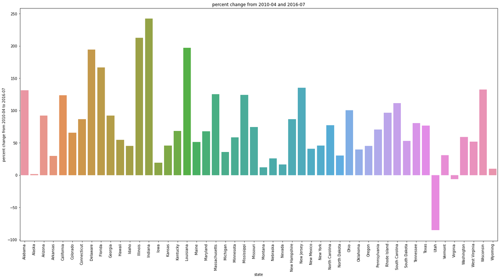

```python
fig, ax = plt.subplots(figsize=(24, 12))
sns.barplot(x='state', y='percent change from 2010-04 to 2016-07',
            data=df_census_data).set(title='percent change from 2010-04 and 2016-07')
ax.set_xticklabels(ax.get_xticklabels(), rotation=90, horizontalalignment='center')
plt.show()
```

## Answer to question 3: What is the overall trend of gun purchases?

```python
df_census_data['percent change from 2010-04 to 2016-07'].describe()
```

```
count     50.000000
mean      74.812868
std       60.006043
min      -85.419403
25%       39.970868
50%       66.755466
75%       99.435134
max      242.233088
Name: percent change from 2010-04 to 2016-07, dtype: float64
```

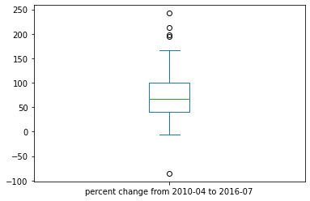

```python
df_census_data['percent change from 2010-04 to 2016-07'].plot(kind='box')
```

### Run bar graph of census data against all states to see if there is a census data is most related to high gun capita - Answer to question 1: What census data is most associated with high gun per capita?

```python
df_census_data_column_list = df_census_data.columns.values.tolist()
df_census_data_column_list.remove('state')
df_census_data_column_list.remove('FemalepersonspercentApril12010')
df_census_data_column_list.remove('Populationpercentchange-April12010(estimatesbase)toJuly12016(V2016)')
df_census_data_column_list.remove('Personsunder5yearspercentJuly12016(V2016)')
df_census_data_column_list.remove('Personsunder5yearspercentApril12010')
df_census_data_column_list.remove('Personsunder18yearspercentJuly12016(V2016)')
df_census_data_column_list.remove('Personsunder18yearspercentApril12010')
df_census_data_column_list.remove('Persons65yearsandoverpercentApril12010')
df_census_data_column_list.remove('FemalepersonspercentJuly12016(V2016)')
```

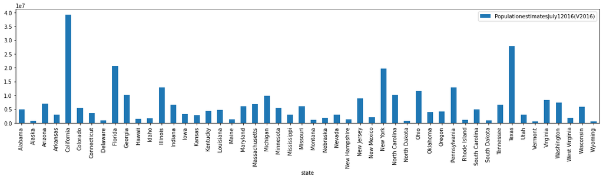

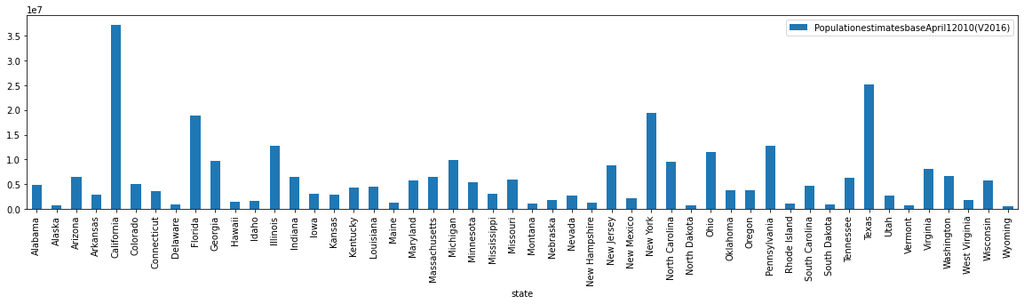

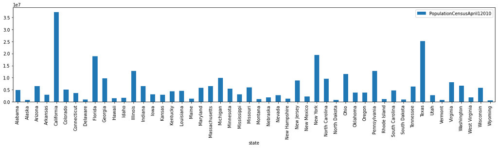

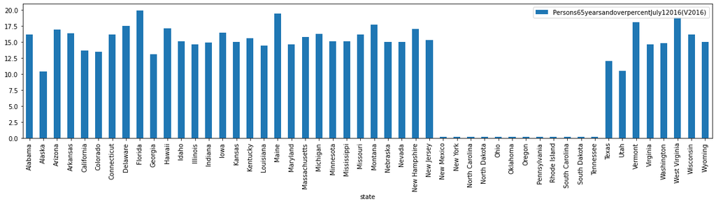

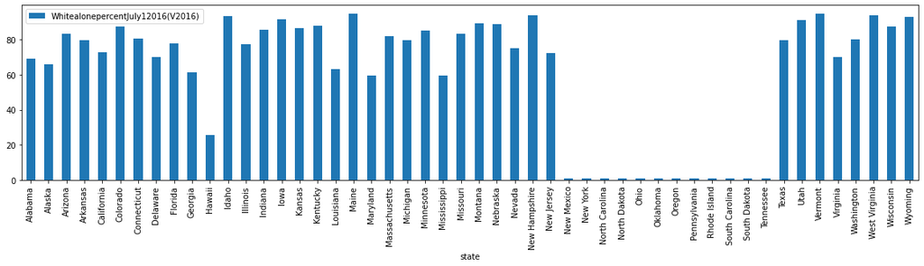

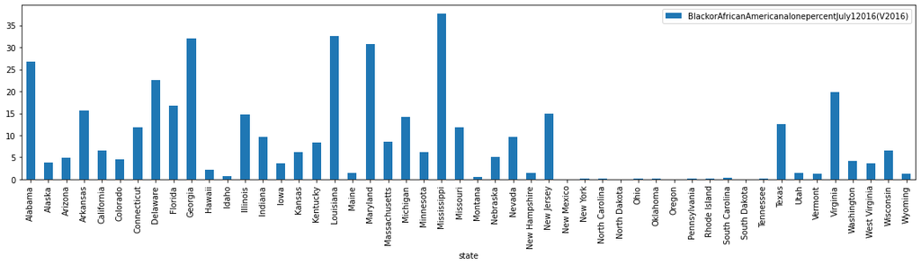

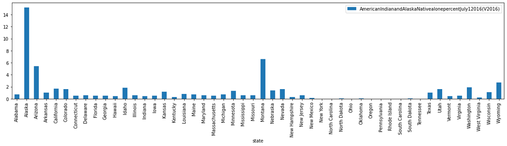

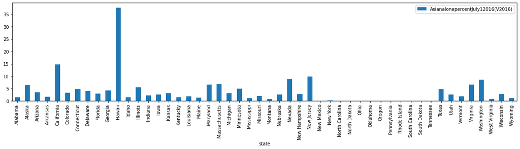

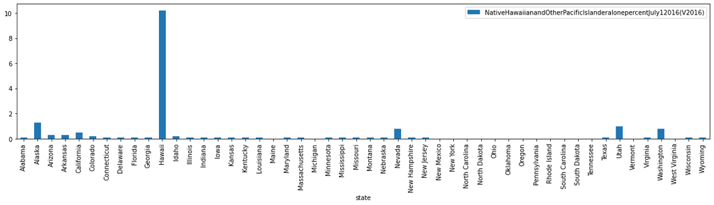

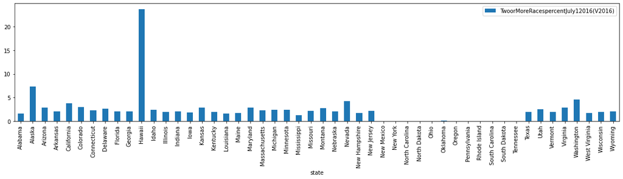

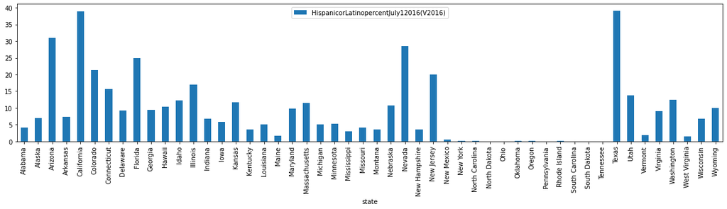

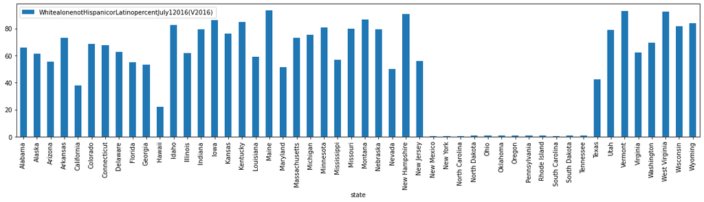

[47 more figures not shown]

```python
for column_name in df_census_data_column_list:
    df_census_data.plot(x='state', y=column_name, kind='bar', figsize=(20, 4));
```

### From above bar graph of state vs different columns in census data, we could not find any ditribution pattern that is similar to the "All Type Check Per Capita 2010-04 and All Type Check Per Capita 2016-07". Therefore, none of the census data is associated with high gun per capita

## Conclusions

> From all the descriptive statistic above, we can see gun per capita increased dramatically between 2010-04 and 2016-07 for most of the states. It seems no information in census data is directly related to the high gun capita. Among all the states, Indiana has the highest increase in percentage while Kentuky has the absolute highest number of arms per capita of the nation

> The **limitation** of this analysis is that gun ownership is based on the number of background check for the gun permit. The actual gun ownership must be related to number of background check, but we need more information to analyze gun ownership. Also, these data set didn't include illegal gun ownership.